# CRISPRa ERV-W differential expression analysis of ERV proviruses

Here we perform differential expression analysis (DEA) of ERV proviruses predictions from retrotector using a unique mapping approach for our CRISPRa experiments targeting ERV-W elements.

The experimental design is CRISPR activation on iPSC and day 30 iNGNs. There are two different guides (LV4009 and LV4070): LV4009 targets LTR17 (ERV-W), and LV4070 is designed to only target ERVW1 (syncytin). LV3470 serves as control targeting LacZ (gene not present in the human genome). There were several experimental batches, for which we account in DESeq2 model.

## Load libraries

Before we start, I load libraries and define some helper functions to visualize the effect as a mean plot (credits to Per Brattås! who wrote the original code for it)

```r
library(data.table)
library(ggplot2)
library(ggpubr)
library(stringr)
library(DESeq2)
## getSignName ##
# Get significantly different gene names.
# Taken from source code of the package deseqAbstraction which is no longer available on github.
# Credits to Per L. Brattås
# Parameters:
# x = results object from deseq
# p = padj threshold for significance
# l = log2FC threshold for significance
getSignName <- function(x,p,l=0) {
  up <- x[!is.na(x$padj) & x$padj < p & x$log2FoldChange > l,]
  down <- x[!is.na(x$padj) & x$padj < p & x$log2FoldChange < -l,]
  return(list(up=rownames(up),down=rownames(down)))
}
## getAverage ##
# Get average expression (normalized by median of ratios) of each of the conditions in a deseq object.
# Taken from source code of the package deseqAbstraction which is no longer available on github.
# Credits to Per L. Brattås
# Parameters:
# dds = deseq object
getAverage <- function(dds) {
  baseMeanPerLvl <- sapply( levels(dds$condition), function(lvl) rowMeans( counts(dds,normalized=TRUE)[,dds$condition == lvl] ) )
  baseSDPerLvl <- sapply( levels(dds$condition), function(lvl) apply( counts(dds,normalized=TRUE)[,dds$condition == lvl],1,sd ) )
  colnames(baseSDPerLvl) <- paste("st.dev:",colnames(baseSDPerLvl),sep="")
  return(list(Mean=baseMeanPerLvl,SD=baseSDPerLvl))
}

meanPlot_cus <- function(exp,test,c1 = "condition 1",c2 = "condition 2",p=.05,l=0,id=F, ttl="",
                         repel=TRUE, col1="darkturquoise", col2="grey", col3="tomato", highlights=NA){
  sign <- getSignName(x = test,p = p,l = l)
  u <- sign$up
  d <- sign$down

  #color up and down sign..
  colVec <- ifelse(test = (rownames(exp) %in% u),
                   yes = col1,
                   no = ifelse(test = (rownames(exp) %in% d),
                               yes = col2, no =col3))
  colVec[is.na(colVec)] <- "steelblue" ## if NA make sure it's not counted as <p
  #size of points
  cexVec <- ifelse(test = (rownames(exp) %in% u),
                   yes = 0.35,
                   no = ifelse(test = (rownames(exp) %in% d),
                               yes = 0.35, no = 0.3))

  exp_log <- as.data.frame(log2(exp[,c(c1, c2)] + 0.5))
  exp_log$Name <- rownames(exp_log)

  exp_log$reg <- factor(ifelse(exp_log$Name %in% u, paste('upregulated in ', c1, ' (', length(u), ')', sep =''),
                               ifelse(exp_log$Name %in% d, paste('downregulated in ', c1,' (', length(d), ')', sep =''), paste('not significant', ' (', (nrow(test) - length(u) - length(d)), ')', sep=''))))

  library(ggrepel)
  if(repel == TRUE){
    plt <- ggplot(exp_log, aes(x=get(c2), y=get(c1), label=Name, color=reg)) + geom_point(aes(size=cexVec), alpha=0.7)+ scale_color_manual(values=c(col2, col3, col1))+ scale_size_continuous(range=c(1,2), guide="none")+ geom_text_repel(data = subset(exp_log, Name %in% u | Name %in% d),direction    = "y", nudge_y = 0.4, nudge_x = -0.5)
  }
  else{
    plt <- ggplot(exp_log, aes(x=get(c2), y=get(c1), color=reg)) + geom_point(aes(size=cexVec), alpha=0.7)+ scale_color_manual(values=c(col2, col3, col1))+ scale_size_continuous(range=c(1,2), guide="none")
  }
  plt <- plt + labs(x=paste("log2(mean ",c2,")",sep=""),
                    y=paste("log2(mean ",c1,")",sep=""),
                    title=paste(ttl, paste(c1," vs. ",c2,sep=""), sep = ': '),
                    subtitle=paste("p-adj < ",p,", log2(fc) > ",l,sep=""))+ theme_bw() +
    theme( plot.title = element_text( size=14, face="bold"), text = element_text(size=15), panel.grid.minor = element_blank(), panel.grid.major = element_blank(), legend.title=element_blank())


  if(id==T) {

    identify(log2(exp[,1]),log2(exp[,2]),labels = rownames(exp))

  }

  if(!is.na(highlights)){
    plt <- plt + geom_point(data=exp_log[highlights,], aes(x=get(c2), y=get(c1)), colour="springgreen3", size=5, shape=1, stroke=2)
  }
  return(plt)

}
```

## Load data and metadata

Here we load the metadata of the samples (and split them by experiment and guide), and the TE count matrices (`te_counts` with all counts).

LV = lentivirus experiment = Experimental batch dpi = Days post induction

```r
samplesheet0 <- fread("./data/samplesheet_0dpi.tab", data.table = F, header = T)
samplesheet30 <- fread("./data/samplesheet_30dpi.tab", data.table = F, header = T)
samplesheet <- rbind(samplesheet0, samplesheet30)

samplesheet_list <- split(samplesheet, f = list(samplesheet$LV, samplesheet$experiment, samplesheet$dpi))

samplesheet_comparisons <- list("Ca_LV4009_E0010405061213_0dpi" = rbind(samplesheet_list$LV4009.E001.0,
                                                                        samplesheet_list$LV4009.E004.0,
                                                                        samplesheet_list$LV4009.E005.0,
                                                                        samplesheet_list$LV4009.E006.0,
                                                                        samplesheet_list$LV4009.E012.0,
                                                                        samplesheet_list$LV4009.E013.0,
                                                                        samplesheet_list$LV3470.E001.0,
                                                                        samplesheet_list$LV3470.E004.0,
                                                                        samplesheet_list$LV3470.E005.0,
                                                                        samplesheet_list$LV3470.E012.0,
                                                                        samplesheet_list$LV3470.E013.0,
                                                                        samplesheet_list$LV3470.E006.0),
                                "Ca_LV4070_E00713_0dpi" = rbind(samplesheet_list$LV4070.E007.0,
                                                                samplesheet_list$LV3470.E007.0,
                                                                samplesheet_list$LV4070.E013.0,
                                                                samplesheet_list$LV3470.E013.0),
                                "Ca_HERVW_LV4009_E012_E013_30dpi" = rbind(samplesheet_list$LV4009.E012.30,
                                                                          samplesheet_list$LV4009.E013.30,
                                                                          samplesheet_list$LV3470.E012.30,
                                                                          samplesheet_list$LV3470.E013.30))

path <- "~/inbox/MN11_HERVW/TEcounts/unique/"
samples <- samplesheet$sample
files <- list.files(path)
files <- files[which(grepl("FL_HERV", files))]
# Check which samples are missing
missing_samples <- samples[!sapply(samples, function(s) {
  any(grepl(s, files))
})]

missing_samples
```

```
## character(0)
```

```r
for(i in 1:length(samples)){
  sample <- samples[i]
  if(i == 1){
    te_counts <- fread(paste(path, sample, "_FL_HERV_count_matrix_2.csv", sep=""), data.table = F)
    colnames(te_counts)[ncol(te_counts)] <- sample
    rownames(te_counts) <- te_counts$Geneid
    row_order <- rownames(te_counts)
  }else{
    tmp <- fread(paste(path, sample, "_FL_HERV_count_matrix_2.csv", sep=""), data.table = F)
    colnames(tmp)[ncol(tmp)] <- sample
    rownames(tmp) <- tmp$Geneid
    te_counts <- cbind(te_counts[row_order,], tmp[row_order,sample,drop=F])
  }
}
```

## TE DEA

Three comparisons to be made:

- LTR17 CRISPRa vs Control in hiPSC
- Syncytin CRISPRa vs Control in hiPSC
- LTR17 CRISPRa vs Control in day 30 iNGNs

```r
te_dds_list <- list()
te_res_list <- list()
te_res_list_df <- list()
te_exp_list <- list()
rownames(te_counts) <- te_counts$Geneid

for(i in names(samplesheet_comparisons)){
  rownames(samplesheet_comparisons[[i]]) <- samplesheet_comparisons[[i]]$samples
  print(i)
  print(c("Batch: ", unique(samplesheet_comparisons[[i]]$seqnum)))
  conditions <- unique(samplesheet_comparisons[[i]]$condition)
  print(c("Conditions: ", conditions))

  effect <- conditions[which(conditions != "Control")]
  test <- paste("condition_", effect ,"_vs_Control", sep = "")
  print(c("Test: ", test))

  te_dds_list[[i]] <- DESeqDataSetFromMatrix(te_counts[,samplesheet_comparisons[[i]]$sample], samplesheet_comparisons[[i]], design = ~ experiment+condition)
  te_dds_list[[i]]$condition <- relevel(te_dds_list[[i]]$condition, "Control")
  te_dds_list[[i]] <- DESeq(te_dds_list[[i]])
  te_res_list[[i]] <- lfcShrink(te_dds_list[[i]], test)
  te_exp_list[[i]] <- getAverage(te_dds_list[[i]])
  te_res_list_df[[i]] <- as.data.frame(te_res_list[[i]])
}
```

```
## [1] "Ca_LV4009_E0010405061213_0dpi"
## [1] "Batch: "
## [1] "Conditions: " "CRISPRa"      "Control"
## [1] "Test: "                       "condition_CRISPRa_vs_Control"
```

[output not shown]

```
## [1] "Ca_LV4070_E00713_0dpi"
## [1] "Batch: "
## [1] "Conditions: " "CRISPRa"      "Control"
## [1] "Test: "                       "condition_CRISPRa_vs_Control"
```

[output not shown]

```
## [1] "Ca_HERVW_LV4009_E012_E013_30dpi"
## [1] "Batch: "
## [1] "Conditions: " "CRISPRa"      "Control"
## [1] "Test: "                       "condition_CRISPRa_vs_Control"
```

[output not shown]

HERV_dup2906 is syncytin

```r
library(EnhancedVolcano)
```

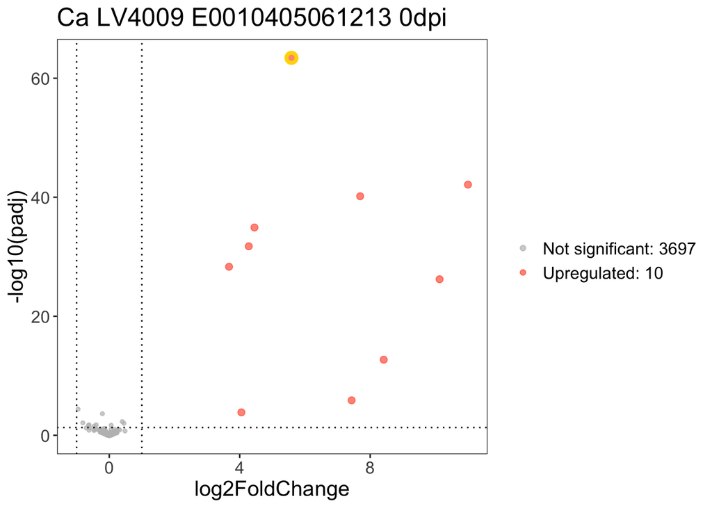

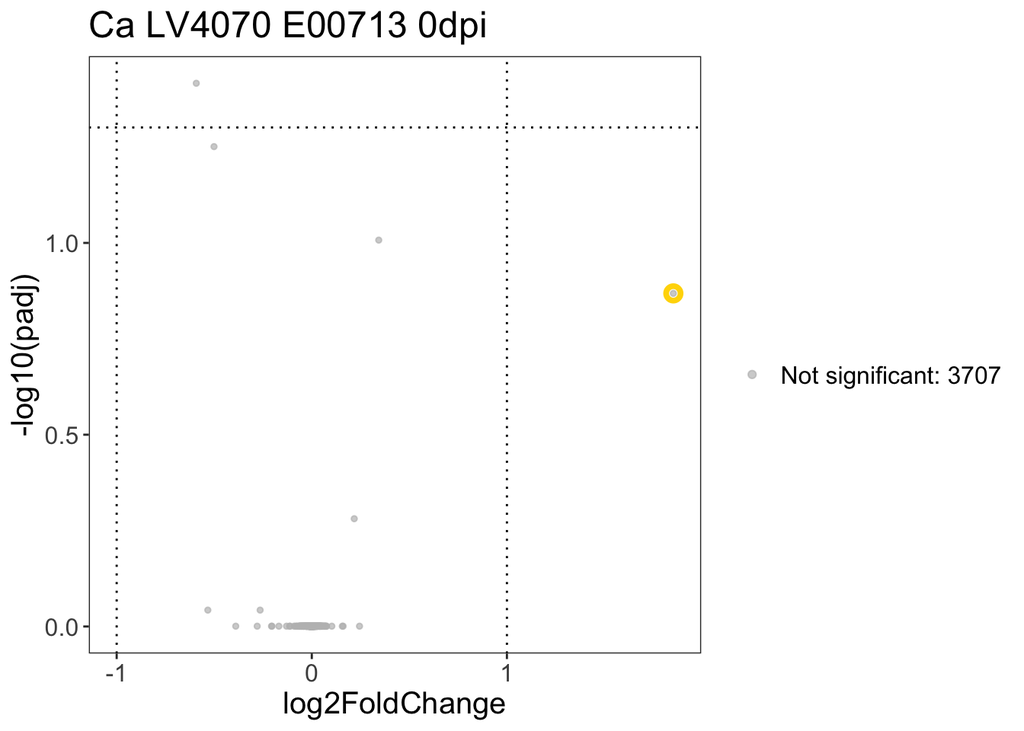

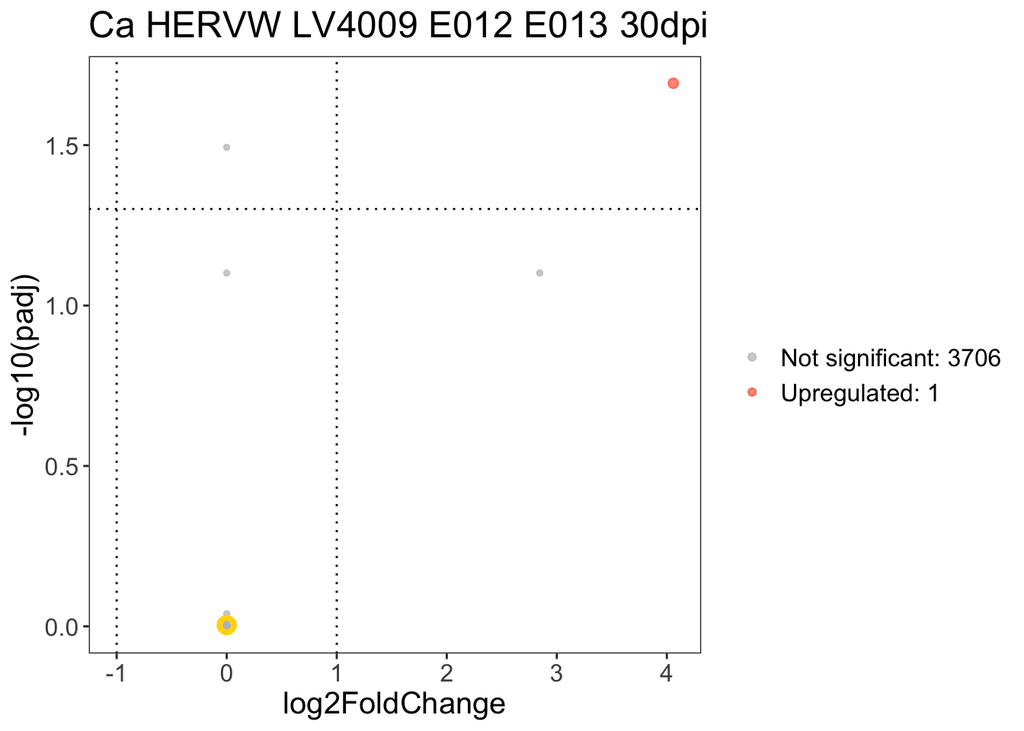

```r
for (i in names(te_res_list_df)) te_res_list_df[[i]]$TE_id <- rownames(te_res_list_df[[i]])

# Now, we visualize things ----
volcano_plots_list <- list()
mean_plots_list <- list()
ma_plots_list <- list()
for(i in names(te_res_list)){
  tmp <- EnhancedVolcano(te_res_list[[i]],
                                             drawConnectors = T,
                                             lab = NA,
                                             x = 'log2FoldChange',
                                             y = 'padj',
                                             pCutoff = 0.05,
                                             FCcutoff = 1)
  tmp$data$Sig <- ifelse(tmp$data$log2FoldChange > 1 & tmp$data$Sig == "FC_P", "Upregulated",
                                             ifelse(tmp$data$log2FoldChange < -1 & tmp$data$Sig == "FC_P", "Downregulated", "Not significant"))
  tmp$data$Sig <- paste(tmp$data$Sig, table(tmp$data$Sig)[tmp$data$Sig], sep = ": ")

  not_sig_lab <- unique(tmp$data$Sig)[startsWith(unique(tmp$data$Sig), "Not significant")]
  up_sig_lab <- unique(tmp$data$Sig)[startsWith(unique(tmp$data$Sig), "Upregulated")]
  down_sig_lab <- unique(tmp$data$Sig)[startsWith(unique(tmp$data$Sig), "Downregulated")]

  point_colours <- c("grey", "tomato", "darkturquoise")
  point_sizes <- c(1,2,1)

  title <- str_replace_all(i, pattern = "_", replacement = " ")

  tmp <- tmp$data
  tmp$TE_subfamily <- sapply(str_split(rownames(tmp), "_dup"), `[[`, 1)
  volcano_plots_list[[i]] <- ggplot(tmp, aes(x=log2FoldChange, y=-log10(padj), colour=Sig, size=Sig)) + geom_point(alpha=0.7) +
    geom_vline(xintercept = 1, linetype="dotted") + geom_vline(xintercept = -1, linetype="dotted") +
    geom_hline(yintercept = -log10(0.05), linetype="dotted") + labs(colour="") +
    scale_color_manual(values = point_colours)  +
    scale_size_manual(values = point_sizes, guide="none") +
    theme_bw() +
    theme(text = element_text(size=15), panel.grid.minor = element_blank(), panel.grid.major = element_blank()) +
    ggtitle(title) + geom_point(data=tmp["HERV_dup2906",], aes(x=log2FoldChange, y=-log10(padj)), colour="gold", size=2, shape=1, stroke=2)

  effect <- unique(samplesheet_comparisons[[i]][which(samplesheet_comparisons[[i]]$condition != "Control"),"condition"])
  mean_plots_list[[i]] <- meanPlot_cus(exp = te_exp_list[[i]]$Mean,
                                       test = te_res_list[[i]],
                                       c1 = effect, c2="Control", p = 0.05, l=1, ttl = title, repel = F)

  ma_plots_list[[i]] <- ggplot(tmp, aes(x=log2(baseMean + 0.5), y=log2FoldChange, colour=Sig, size=Sig)) +
    geom_point(alpha=0.7) +
    theme_bw() +
    theme(panel.grid.major = element_blank(), panel.grid.minor = element_blank()) +
    scale_color_manual(values = point_colours) +
    scale_size_manual(values = point_sizes, guide="none") + ggtitle(title)
}

openxlsx::write.xlsx(te_res_list_df, file = "./data/ERV_DEA.xlsx")

volcano_plots_list
```

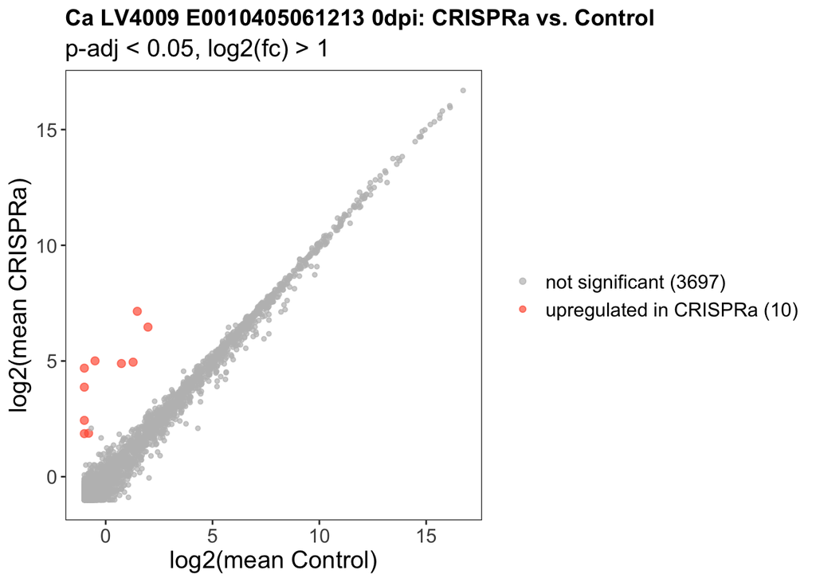

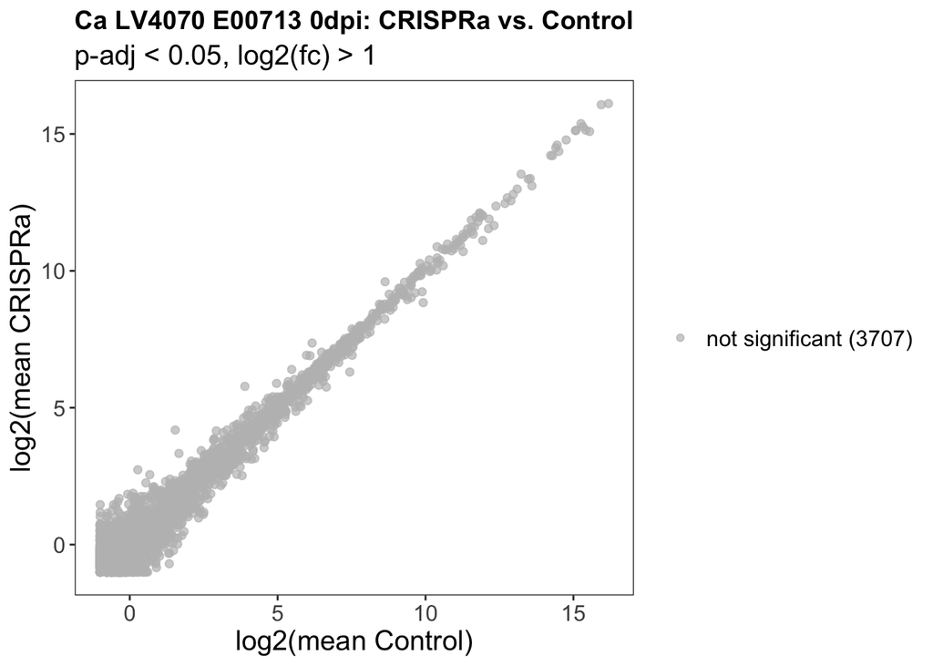

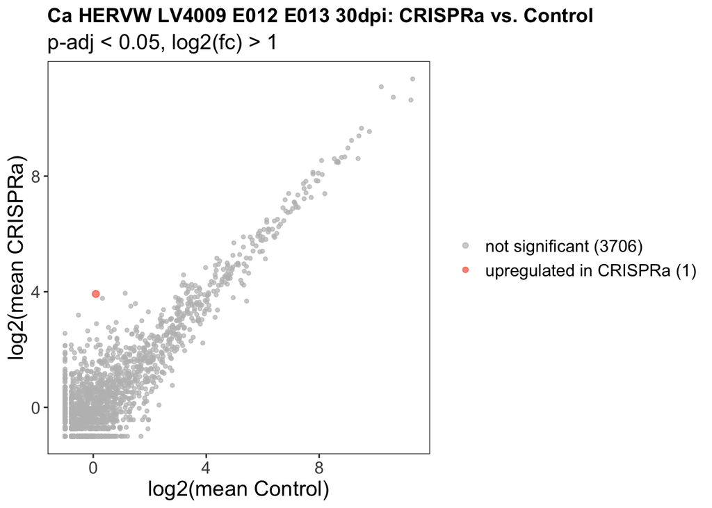

```r
mean_plots_list
```

```r
save.image("./data/2_ERV_DEA.Rdata")
```